# Using huggingface for NLP

## What's hugging face

[Hugging face](https://github.com/huggingface) is an AI community for knowledge sharing. Many companies share their models (many of them pretrained) for different AI tasks. It is best known for its collection of [transformer models](https://huggingface.co/docs/transformers/index#supported-models).

We are going to build a very simple German-to-English translator based on huggingface datasets. We are going to use the packages transformers and datasets, you can install them in your virtual environment with conda, using the channel "huggingface".

The example uses a transformer model mt5, [here](https://ai.googleblog.com/2020/02/exploring-transfer-learning-with-t5.html) a more detailed explanation of the model. The different models on huggingface may be different in their input/output formats, naming requirements, etc., and you will need to read their documents (and often also their source code) in detail if you encounter problems.

## Crash course on transformers

In the previous classes we went through recurrent neural network and LSTM. These are methods for sequential data learning, such as text. However, they are very slow and have trouble parallelizing the computation. That's why transformer as a successor to these other methods became the industry standard for sequential data learning.

### Seq2seq

There are different [types of applications](https://bdtechtalks.com/2022/05/02/what-is-the-transformer/) regarding sequential data.

[figure not shown]

Vector to sequence has one input and a sequence of outputs. Applications include image-to-text conversion. Sequence to vector has sequence data as input and one output, applications include: text classification, sentiment scores, etc. Our example is a sequence to sequence model: both input and output are sequence data, for example in question-and-answer chatbots, machine translation, etc.

### Transformer

[figure not shown]

The structure looks awfully complicated. But we already went through most of the things in there. What parts can you recognize?

The input and output embedding, the feed-forward, normalization, linear, softmax layers. The encoder-decoder structure. The attention layer is a bit different from what we've seen before. But the concept is the same (we are not going to get into the details, there are links at the end of the previous class where you can read about it). That leaves only the positional embedding.

### Positional embedding

The idea is to not only represent words with vectors, but also extract relative positional information between the words in a document. There's a very good explanation [here](https://towardsdatascience.com/master-positional-encoding-part-i-63c05d90a0c3), explaining the choice of the trigonometric functions for positional encoding.

### Sentence piece for tokenization

The tokenizer we use in our model is a bit different from the previous classes when we assume that words are separated by spaces. There are languages such as Chinese that do not use space. So the tokenization works differently. We use [sentence piece](https://github.com/google/sentencepiece). We are going to show how it tokenizes the words later.

You have to install the sentencepiece package into your virtual environment for the t5 tokenizer to work.

## The example

Create a virtual environment for this example. Update the packages to the newest version, e.g., python3.9. If you install with conda, use `-c huggingface` channel for [transformers](https://huggingface.co/docs/transformers/installation#install-with-conda) and [datasets](https://huggingface.co/docs/datasets/installation#conda) packages. Also install the [sentencepiece](https://github.com/google/sentencepiece#installation) package.

Huggingface models can run on both pytorch and tensorflow. In this example we'll use pytorch. Be sure to have the newest version of pytorch in the virtual environment.

```python
#!pip install sentencepiece
from transformers import (MT5ForConditionalGeneration,
                          MT5Tokenizer,get_scheduler)
from datasets import load_dataset
import torch
from torch.optim import AdamW
from matplotlib import pyplot as plt
import warnings
warnings.filterwarnings('ignore')
```

Next we download the data from huggingface directly. You can specify train and test data differently.

```python
train_ds, test_ds = load_dataset('opus_books','de-en',
                                 split=['train[100:1100]','train[-100:]'])
```

We use the MT5 pretrained models from google. The tokenizer and model is defined as below:

```python
tokenizer = MT5Tokenizer.from_pretrained('google/mt5-small')
mdl = MT5ForConditionalGeneration.from_pretrained('google/mt5-small')
```

To see how the tokennizer works with sentence piece, you can print the encoded and decoded index and tokens. Different from tokenizers based on space, this tokenizer separates the word "Dieser" into different parts. the `</s>` is only a special token for end of sequence.

```python
print('encode: {}'.format(tokenizer.encode('Dieser')))
print('decode: {} = {} + {} + {}'.format(tokenizer.decode([10092,286,1]),tokenizer.decode(10092),
                                   tokenizer.decode(286),tokenizer.decode(1)))
print('vocab size: {}'.format(tokenizer.vocab_size))
```

```
encode: [10092, 286, 1]
decode: Dieser</s> = Diese + r + </s>
vocab size: 250100
```

We use an optimizer from pytorch, and a simple scheduler for constant learning rates from huggingface.

```python
source_lang = 'de'
target_lang = 'en'
prefix = 'translate German to English: '

optimizer = AdamW(mdl.parameters(), lr=5e-5)
lr_scheduler = get_scheduler(name='constant', optimizer=optimizer)
```

Training process should be something you are familiar with, from the previous classes. Everything is the same except we have a model that is pretrained on some other data.

This retraining is called `fine-tuning` of the pretrained model. It is a concept in transfer learning, where a different, sometimes much smaller dataset is used to learn new tasks, after a model has been trained extensively. The pretrained seq2seq model may not be suitable for our German-to-English translation task, therefore we'd need to fine-tune it.

```python
total_loss = []
avg_loss = []
for i in range(len(train_ds)):
    text_de = prefix + train_ds[i]['translation'][source_lang]
    text_en = train_ds[i]['translation'][target_lang]

    # prefix is added to tell the model what to do.
    text_train = tokenizer(prefix+text_de,
                       text_target=text_en,
                       max_length=32,padding='max_length', truncation=True,
                       return_tensors="pt")
    mdl.zero_grad()
    # "**" turns text_train input dictionary into key arguments
    # in the format of: (key1=value1,key2=value2)
    output = mdl(**text_train)
    loss = output.loss
    if loss:
        total_loss.append(loss)
    if i%100==0:
        avg_loss.append(sum(total_loss)/len(total_loss))
        print(avg_loss[-1])
        total_loss = []

    loss.backward()
    optimizer.step()
    lr_scheduler.step()
```

```
tensor(27.4025, grad_fn=<DivBackward0>)
tensor(17.5287, grad_fn=<DivBackward0>)
tensor(12.5574, grad_fn=<DivBackward0>)
tensor(7.9178, grad_fn=<DivBackward0>)
tensor(8.2283, grad_fn=<DivBackward0>)
tensor(7.2941, grad_fn=<DivBackward0>)
tensor(6.3715, grad_fn=<DivBackward0>)
tensor(6.2691, grad_fn=<DivBackward0>)
tensor(5.2271, grad_fn=<DivBackward0>)
tensor(4.8643, grad_fn=<DivBackward0>)
```

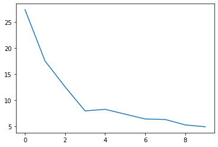

```python
plt.plot([x.item() for x in avg_loss])
```

We'll just show one translation from the testset. The result is not satisfactory.

What can you change?

```python
text_de = prefix + test_ds[0]['translation'][source_lang]

text = tokenizer(prefix+text_de,
                 max_length=32,padding=True, truncation=True,
                 return_tensors="pt")


output = mdl.generate(**text,max_new_tokens=32)
decoded = tokenizer.decode(output[0], skip_special_tokens=True)
print(text_de)
print(decoded)
```

```
translate German to English: Die Summe belief sich auf etwas über zwölftausend Dollar.
<extra_id_0> would be a few thousand Dollars.
```

### Homework

1. find a measurement for the quality of the translation. Run and get the score on the testset.
2. Make changes to the code and improve on the measurement.